# Assessment_3

Emelia Appiah

2026-10-03

# Question 1: Reproducing Figures

The cleaned labels for both gender and ethnicity are used instead of the codes in the raw dataset.

To keep the same colour assignment as the original figures `gender` was ordered with `Male` first. (code `1` = male, code `2` = female). The ethnicity categories were also ordered following the original `RIDRETH3` codes (1 = Mexican, 2 = Other Hispanic, 3 = White, 4 = Black, 6 = Asian, 7 = Other).

The age histogram in the original figure only contained adults, so the data was restricted to participants aged 20 and older. Bins were set with `binwidth = 5`and `boundary = 20`, so each bin covers exactly five years of age.

## Figures

### Individual Figures

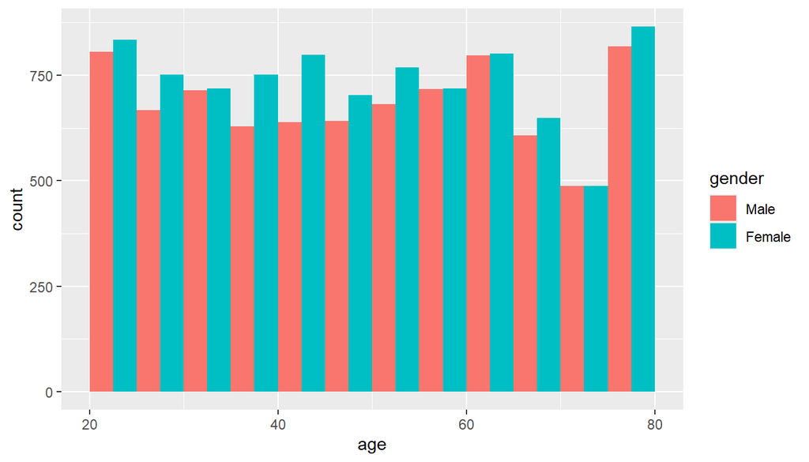

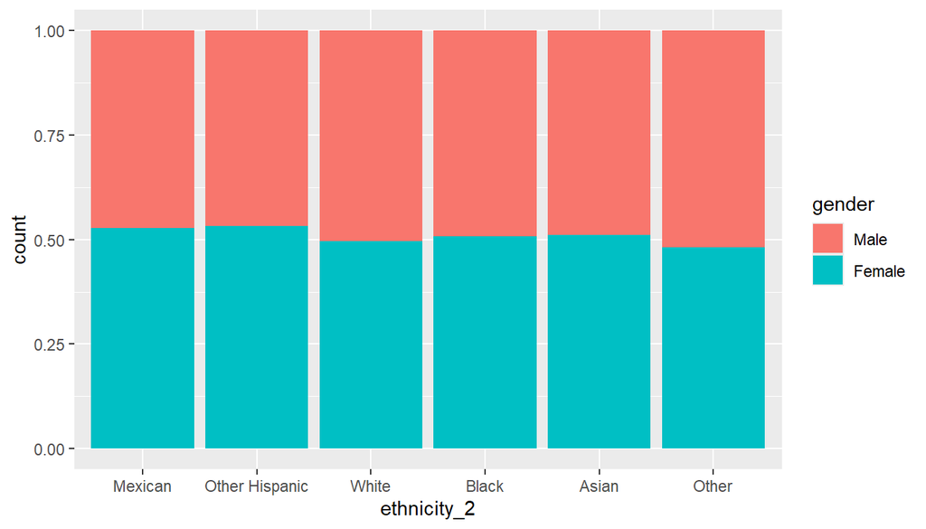

### Combined Figures

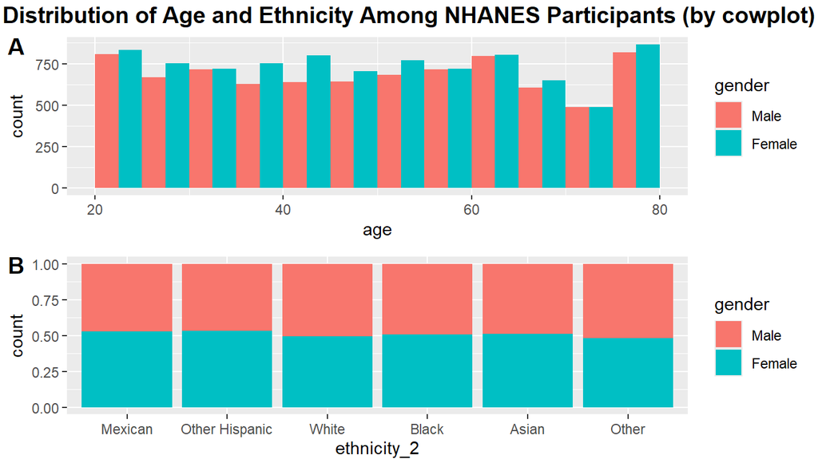

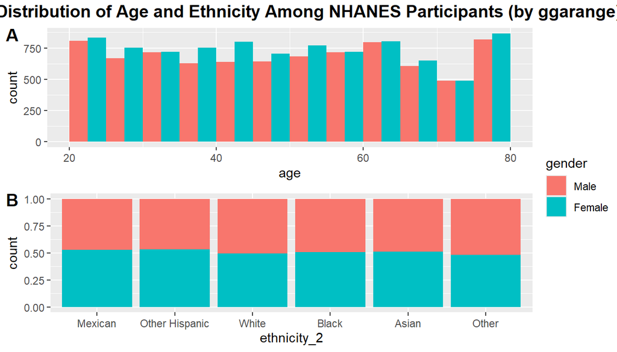

**Comparing `plot_grid()` and `ggarrange()`.** For these two plots, the `ggarrange()` layout looks cleaner and is the better choice although both functions stack the two plots and add panel labels.

With the `align = "v"` the `plot_grid()` output lines up the two panels so their plotting areas share the same left edge. However,`plot_grid()` keeps each plot’s own legend, so the same `gender` legend is drawn twice, which wastes space and adds nothing.

`ggarrange()` on the other hand has a built-in `common.legend = TRUE` option that draws one shared legend for the whole figure. Because both plots use the same fill variable with the same colors, a single legend is all the reader needs, and the panels get more width.

# Question 2: Visualizing key characteristics

[output not shown]

Number of missing values per variable

| age | gender | ethnicity_1 | ethnicity_2 |
| --- | --- | --- | --- |
| 0 | 0 | 0 | 0 |

None of the four variables had missing values, so every one of the 29,400 participants is included in the plots below.

## Age distribution

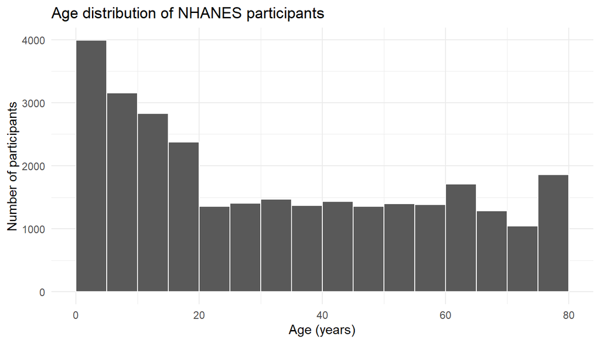

## Gender

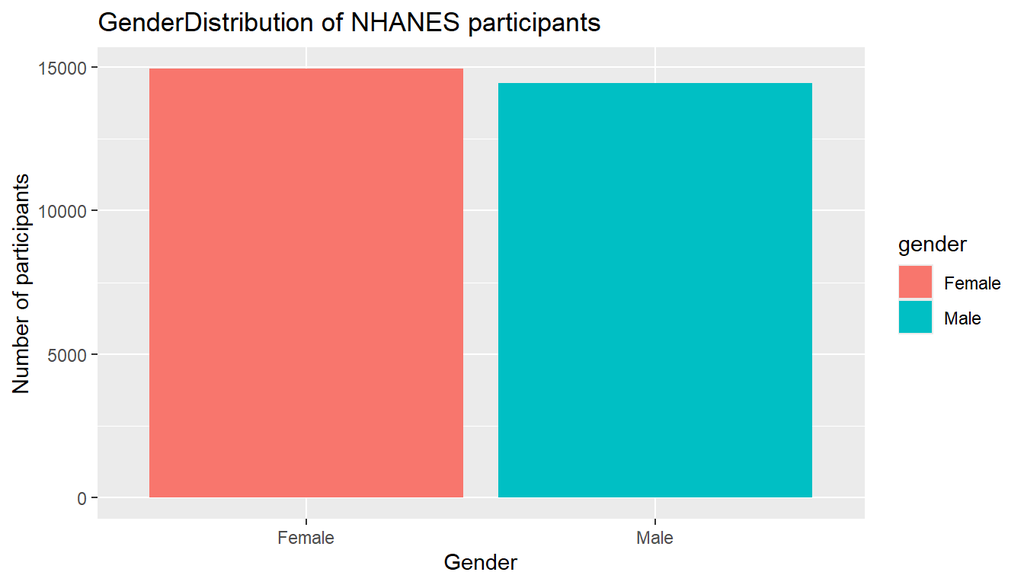

The sample is close to balanced, with 14,948 females (50.8%) and 14,452 males. There were no missing values.

## Ethnicity

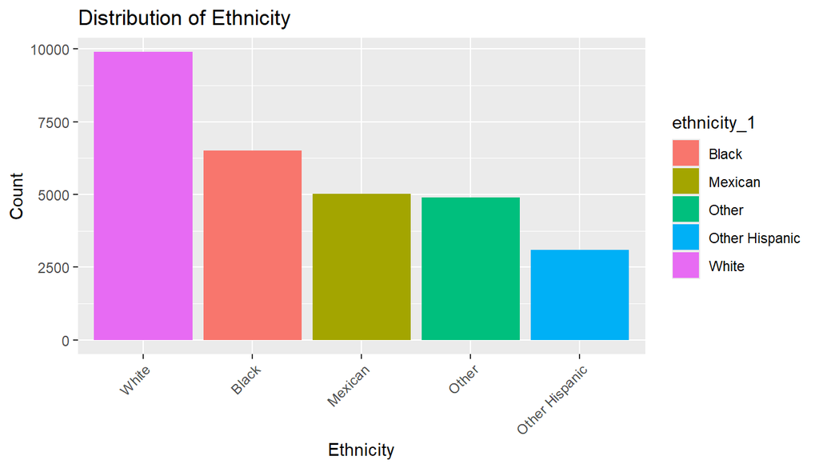

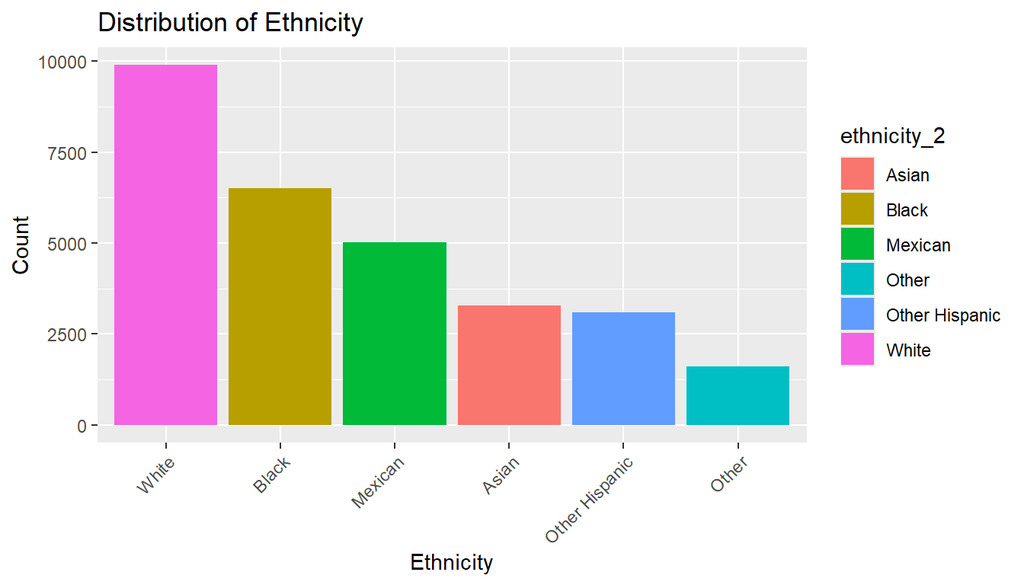

White is the largest group (9,890 participants), followed by Black and Mexican participants. The two variables only differ in one place: `ethnicity_1` has five categories, while `ethnicity_2` has six, because it separates **Asian** participants out of the **Other** category.

Cross-tabulation of the two ethnicity variables

|  | Asian | Black | Mexican | Other | Other Hispanic | White |
| --- | --- | --- | --- | --- | --- | --- |
| Black | 0 | 6511 | 0 | 0 | 0 | 0 |
| Mexican | 0 | 0 | 5018 | 0 | 0 | 0 |
| Other | 3284 | 0 | 0 | 1609 | 0 | 0 |
| Other Hispanic | 0 | 0 | 0 | 0 | 3088 | 0 |
| White | 0 | 0 | 0 | 0 | 0 | 9890 |

The cross-tabulation shows the two variables agree for every participant outside the “Other” group. In `ethnicity_1`, “Other” holds 4,893 people, of whom 3,284 (67%) are identified as Asian in `ethnicity_2`.

**Decision:** i will keep `ethnicity_2` because it contains all the information in `ethnicity_1` plus a separate Asian category, so nothing is lost by dropping `ethnicity_1`. Lumping Asian participants into a mixed “Other” group hides a large, identifiable group and makes “Other” hard to interpret, which matters when the outcome (here, blood pressure) may differ between groups.

# Question 3: Improving a ggplot figure

## Critique and Improvement of the Original Figure

The original figure showed the absolute weight of each participant over the 16-week study period. Although it provided information about individual weight trajectories, it was difficult to determine how much each participant’s weight changed relative to their starting point. Because participants began the study at different weights, comparing the lines directly did not clearly show the magnitude of weight loss or gain. For example, a participant who started at a higher weight may appear higher on the graph even if their percentage or absolute weight change was similar to that of another participant.

The original figure also lacked an informative overall title or subtitle to explain the purpose of the visualization and guide a reader’s interpretation. Although the axes are labeled “Weight” and “Week,” the reader must infer that the figure is intended to show changes in participants’ weight during the diet study. A descriptive title and subtitle would provide context and communicate the main purpose of the figure more clearly.

To improve the visualization, the change in weight for each participant was calculated from the baseline weight at week 0 and the weight at each subsequent week using `Weight - baseline`. This placed all participants on a common baseline of zero, making the direction and magnitude of weight change easier to compare. A dashed horizontal line at zero was added as a visual reference, so values below zero represent weight loss and values above zero represent weight gain.

`facet_wrap()` was used to create a separate panel for each participant. This removed the overlapping trajectories from a single plot and makes each participant’s pattern easier to follow. Rather than assigning a separate color to every participant, participants were grouped into three response categories: “Lost weight,” “No change,” and “Gained weight.” This reduced the number of colors and gave the visualization a clearer story about the overall response patterns.

A descriptive title, “Change in Weight From Baseline,” and a subtitle explaining that the weight change is measured relative to each participant’s week-0 weight. These additions provided immediate context and made the purpose of the visualization clear before a reader examined the individual trajectories.

Finally, `scale_x_continuous()` was used to display the study weeks at 0, 4, 8, 12, and 16 and `scale_y_continuous()` to provide consistent weight-change reference points. Overall, these changes made the figure less cluttered, easier to interpret, and more directly aligned with the goal of showing how each participant’s weight changed from their baseline.

## Improved figure

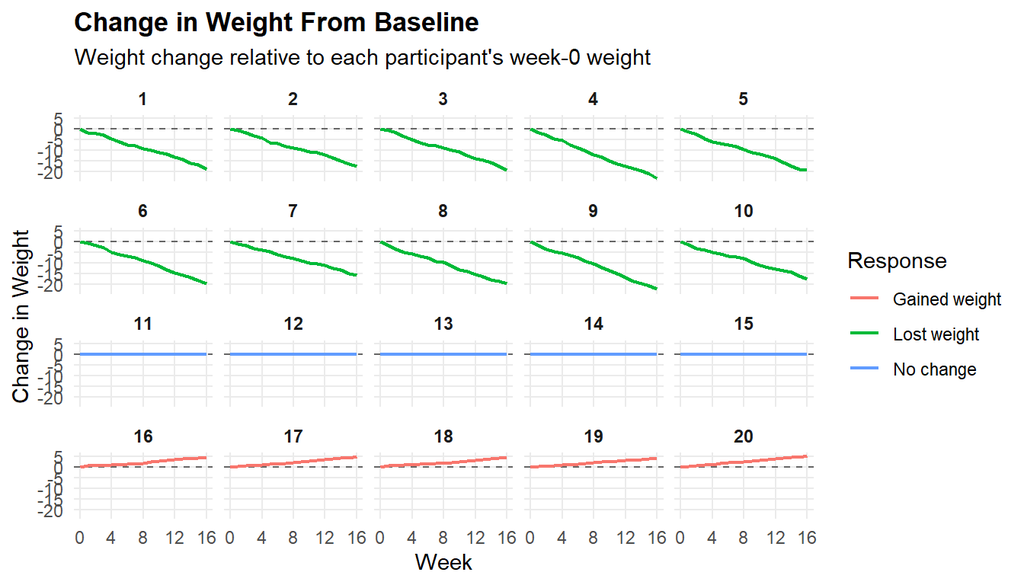

The **gained weight** group included 5 participants, with a mean weight change of 4.5 units and a mean percentage change of 5.4%.

The **no change** group included 5 participants, with a mean weight change of 0 units and a mean percentage change of 0%.

Overall, the summary showed that weight loss was the most common response at week 16, with the lost-weight group showing a substantially larger average change from baseline than the gained-weight group.

Weight change at week 16 by response group

| Response group | n | Mean weight change | Mean change (%) |
| --- | --- | --- | --- |
| Gained weight | 5 | 4.5 | 5.4 |
| Lost weight | 10 | -19.3 | -23.4 |
| No change | 5 | 0.0 | 0.0 |

# Question 4: Exploring relationships through visualizations

## Relationship between age, gender, and systolic blood pressure

The analysis began with four systolic blood pressure (SBP) measurements for each participant, which were combined to calculate a single average SBP. Participants with missing age, gender, or average SBP were then excluded, resulting in a final analytical sample of 21604 participants. This represents 73.5% of the original 29400 participants, with 7796 participants excluded because they did not have complete information required for the analysis.

The average systolic blood pressure was classified into four categories: Normal, Elevated, Stage 1 hypertension, and Stage 2 hypertension. Across the final sample, the most common category was Normal, with 12289 participants. This provided a starting point for examining whether the distribution of blood pressure categories differed across age groups and between genders.

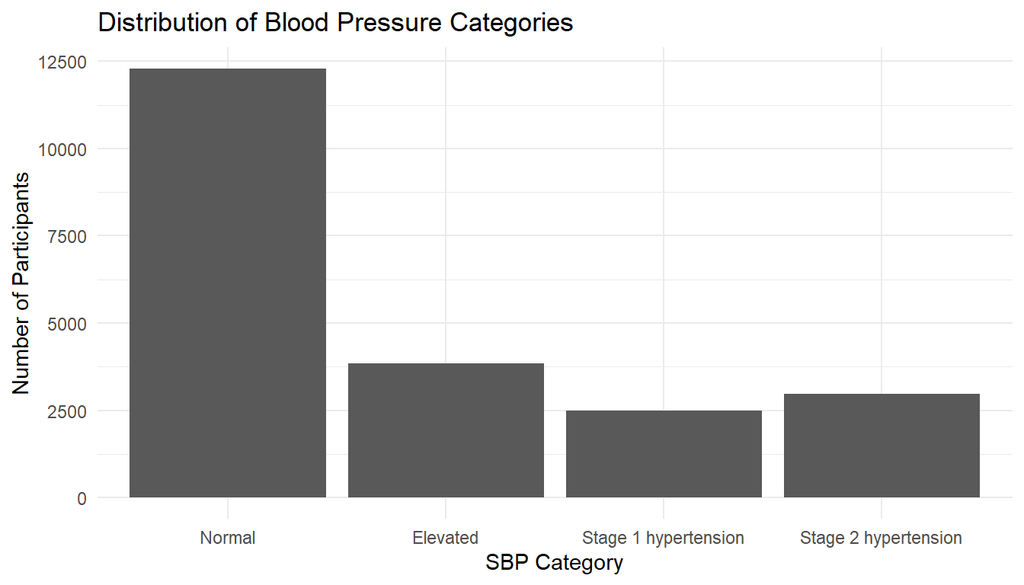

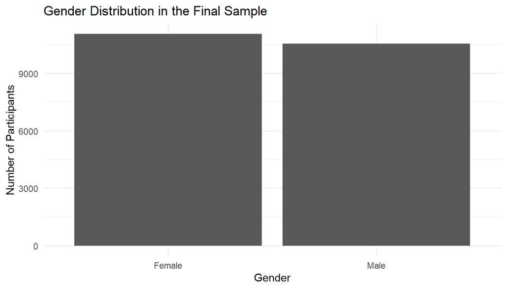

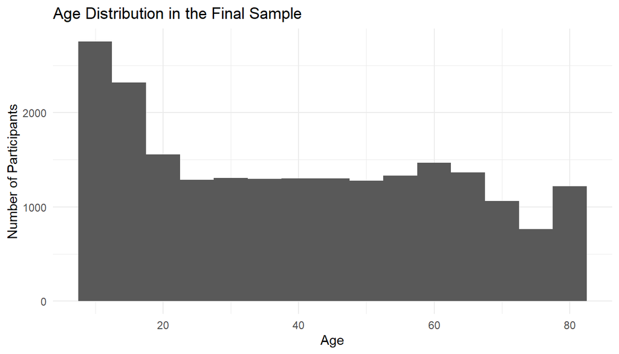

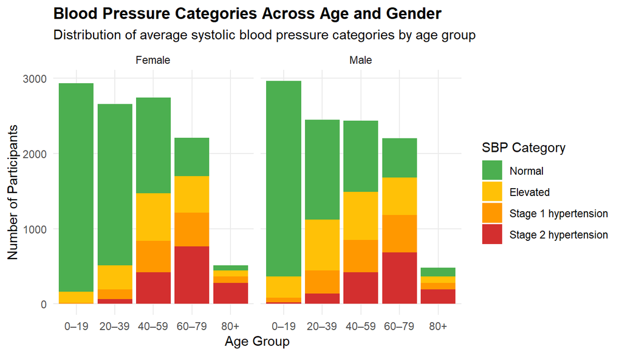

Distribution of systolic blood pressure categories by age group and gender

| Age Group | Gender | N | Normal (%) | Elevated (%) | Stage 1 (%) | Stage 2 (%) | Stage 1 + 2 (%) |
| --- | --- | --- | --- | --- | --- | --- | --- |
| 0–19 | Female | 2937 | 94.6 | 4.8 | 0.5 | 0.0 | 0.6 |
| 0–19 | Male | 2967 | 87.7 | 9.5 | 2.2 | 0.6 | 2.8 |
| 20–39 | Female | 2660 | 80.6 | 12.1 | 4.9 | 2.4 | 7.3 |
| 20–39 | Male | 2451 | 54.2 | 27.7 | 12.6 | 5.5 | 18.1 |
| 40–59 | Female | 2743 | 46.4 | 23.0 | 15.3 | 15.3 | 30.6 |
| 40–59 | Male | 2440 | 38.8 | 26.2 | 17.6 | 17.3 | 35.0 |
| 60–79 | Female | 2209 | 23.0 | 22.1 | 20.2 | 34.6 | 54.9 |
| 60–79 | Male | 2204 | 23.9 | 22.5 | 22.6 | 31.0 | 53.6 |
| 80+ | Female | 512 | 12.7 | 15.6 | 17.0 | 54.7 | 71.7 |
| 80+ | Male | 481 | 23.9 | 18.1 | 17.7 | 40.3 | 58.0 |

The visualization for blood pressure categories across age and gender showed how systolic blood pressure categories were distributed across the five age groups for each gender. The distribution was examined by comparing the relative size of the blood pressure categories within each age group. In particular, the proportion of participants in the higher blood pressure categories can be compared across the younger and older age groups.

The largest age group in the sample is 0–19, while the smallest is 80+. These differences in group size are important when interpreting the visualization because the bars represent participant counts rather than percentages.

The table and visualization show how average systolic blood pressure categories are distributed across age groups and gender. Among the youngest participants (0–19), the Normal category represents a substantial share of participants. As age increases, the distribution shifts toward the higher blood pressure categories.

The highest combined percentage of Stage 1 and Stage 2 hypertension occurs among Female participants in the 80+ age group, where 71.7% are classified in one of these two categories. In contrast, the lowest combined percentage occurs among Female participants in the 0–19 age group, at 0.6%.

The visualization makes this pattern particularly visible: the green Normal sections are more prominent among younger participants, while the orange and red sections representing Stage 1 and Stage 2 hypertension become more prominent in older age groups. The table provides the corresponding percentages, allowing the distributions to be compared more directly across groups.

Overall, the results show a clear shift in the distribution of systolic blood pressure categories across age groups, with higher blood pressure categories becoming more prominent among older participants.

The differences between females and males was also be examined within each age group. Among participants aged 0–19, females had a higher proportion in the Normal category than males (94.6% versus 87.7%), while the combined proportion with Stage 1 or Stage 2 hypertension is lower among females (0.6% versus 2.8%).

This difference was more noticeable in the 20–39 age group, where 80.6% of females are in the Normal category compared with 54.2% of males. The corresponding percentages for Stage 1 and Stage 2 hypertension combined are 7.3% for females and 18.1% for males.

The gender difference was smaller in the 40–59 and 60–79 age groups. For example, among participants aged 60–79, the proportion with Stage 1 or Stage 2 hypertension is 54.9% among females and 53.6% among males. However, the pattern changes again among participants aged 80 and older. In this group, females have a higher proportion classified with Stage 1 or Stage 2 hypertension (71.7%) than males (58%). In particular, Stage 2 hypertension accounts for 54.7% of females compared with 40.3% of males.

Taken together, the table shows that the gender differences are not consistent across all age groups. Males have a greater share of higher blood pressure categories in the younger age groups, while the difference narrows among participants aged 40–79 and reverses among those aged 80 and older, where females have a greater share of Stage 1 and Stage 2 hypertension.